# Age EDA

### Data import

```r
credit = read.csv("credit_card_data.csv", fileEncoding="UTF-8")
jeju = read.csv("jeju_financial_life_data.csv")

credit = credit[-1,] #첫번째 데이터 오류 존재
str(credit)
```

```
## 'data.frame':    3887 obs. of  26 variables:
##  $ pop_cd                          : chr  "L011" "L011" "L011" "L011" ...
##  $ year                            : int  2016 2016 2016 2016 2016 2016 2016 2016 2016 2016 ...
##  $ month                           : int  2 3 4 5 6 7 8 9 10 11 ...
##  $ avg_score                       : int  773 771 770 771 771 772 772 772 773 775 ...
##  $ avg_rat                         : int  4 4 4 4 4 4 4 4 4 4 ...
##  $ city                            : chr  "서울" "서울" "서울" "서울" ...
##  $ sex                             : chr  "" "" "" "" ...
##  $ ages                            : chr  "10대" "10대" "10대" "10대" ...
##  $ population                      : int  380000 387000 412000 414000 410000 407000 403000 399000 395000 390000 ...
##  $ num_opencard                    : num  1.71 1.75 1.76 1.75 1.75 1.75 1.75 1.74 1.73 1.71 ...
##  $ num_usecard                     : num  0.96 0.95 0.92 0.94 0.96 0.97 0.98 0.99 0.98 0.98 ...
##  $ monthly_card_spend              : int  170000 190000 200000 170000 190000 180000 170000 190000 180000 180000 ...
##  $ monthly_lc                      : int  31140000 30230000 30430000 31210000 29520000 28400000 29170000 29870000 30420000 29560000 ...
##  $ monthly_loan                    : int  28910000 28180000 27710000 27620000 27020000 25800000 26480000 26910000 27760000 27970000 ...
##  $ monthly_bk_loan                 : int  25850000 25110000 24630000 24390000 23740000 22140000 23000000 23140000 23850000 24180000 ...
##  $ monthly_cd_loan                 : int  190000 170000 190000 210000 200000 220000 240000 240000 190000 170000 ...
##  $ monthly_installments_loan       : int  510000 490000 510000 490000 410000 520000 400000 420000 460000 560000 ...
##  $ monthly_insurance_loan          : int  220000 210000 240000 340000 320000 320000 140000 210000 190000 120000 ...
##  $ monthly_sbk_loan                : int  1020000 1140000 1340000 1490000 1630000 1670000 1720000 1850000 1930000 2040000 ...
##  $ loan_commitment                 : int  680000 640000 510000 640000 680000 610000 830000 920000 890000 880000 ...
##  $ inst_rep_loanb                  : int  4660000 4370000 4770000 4740000 4730000 4680000 4950000 5240000 5860000 5740000 ...
##  $ ls_rep_loanb                    : int  23300000 22930000 22160000 21960000 21380000 20230000 20400000 20450000 20780000 21150000 ...
##  $ credit_loan                     : int  8260000 8300000 9460000 9660000 9470000 8790000 9660000 10060000 9720000 9440000 ...
##  $ mortgage_loan                   : int  42410000 41710000 41040000 40850000 40130000 38970000 40770000 41590000 43070000 43600000 ...
##  $ credit_card_payment             : int  4000 3000 4000 3000 4000 4000 4000 5000 4000 4000 ...
##  $ credit_card_installments_payment: int  1000 1000 1000 1000 2000 2000 2000 2000 2000 2000 ...
```

### Credit EDA

1. pop_cd : L시리즈 - 지역코드+나이대, Y시리즈 - 성별+나이대

```r
#L시리즈 - 성별 정보 없음.
credit %>%
  filter(str_sub(pop_cd,1,1) == "L" , sex=="") # 3455
```

```
##      pop_cd year month avg_score avg_rat city sex ages population num_opencard
## 1      L011 2016     2       773       4 서울     10대     380000         1.71
## 2      L011 2016     3       771       4 서울     10대     387000         1.75
## 3      L011 2016     4       770       4 서울     10대     412000         1.76
## 4      L011 2016     5       771       4 서울     10대     414000         1.75
## 5      L011 2016     6       771       4 서울     10대     410000         1.75
## 6      L011 2016     7       772       4 서울     10대     407000         1.75
## 7      L011 2016     8       772       4 서울     10대     403000         1.75
## 8      L011 2016     9       772       4 서울     10대     399000         1.74
## 9      L011 2016    10       773       4 서울     10대     395000         1.73
## 10     L011 2016    11       775       4 서울     10대     390000         1.71
## 11     L011 2016    12       775       4 서울     10대     387000         1.71
## 12     L011 2017     1       776       4 서울     10대     386000         1.69
## 13     L011 2017     2       774       4 서울     10대     355000         1.75
## 14     L011 2017     3       772       4 서울     10대     360000         1.78
```

[output cut: 17265 more lines]

```r
#Y시리즈 - 지역 정보 없음.
credit %>%
  filter(str_sub(pop_cd,1,1) == "Y" , city=="") #432
```

```
##     pop_cd year month avg_score avg_rat city  sex ages population num_opencard
## 1      Y10 2016     1       811       2      남자 10대     960000         1.16
## 2      Y10 2016     2       767       4      남자 10대    1144000         1.59
## 3      Y10 2016     3       765       4      남자 10대    1168000         1.62
## 4      Y10 2016     4       764       4      남자 10대    1211000         1.66
## 5      Y10 2016     5       765       4      남자 10대    1216000         1.66
## 6      Y10 2016     6       765       4      남자 10대    1209000         1.67
## 7      Y10 2016     7       766       4      남자 10대    1203000         1.67
## 8      Y10 2016     8       766       4      남자 10대    1198000         1.67
## 9      Y10 2016     9       766       4      남자 10대    1192000         1.67
## 10     Y10 2016    10       767       4      남자 10대    1182000         1.65
## 11     Y10 2016    11       768       4      남자 10대    1170000         1.64
## 12     Y10 2016    12       769       4      남자 10대    1174000         1.61
## 13     Y10 2017     1       770       4      남자 10대    1182000         1.58
## 14     Y10 2017     2       769       4      남자 10대    1190000         1.56
```

[output cut: 2150 more lines]

```r
#L시리즈, Y시리즈 분류
area_credit = credit %>%
  filter( str_sub(pop_cd,1,1) == "L" ) %>%
  dplyr::select( -sex)
sex_credit = credit %>%
  filter( str_sub(pop_cd,1,1) == "Y" ) %>%
  dplyr::select( -city)

#연령대(ages), sex, city의 정보를 다른 변수가 대체하므로 pop_cd 제거
is.na(area_credit$ages) %>% which
```

```
## integer(0)
```

```r
is.na(sex_credit$ages) %>% which
```

```
## integer(0)
```

```r
area_credit = area_credit[,-1]
sex_credit = sex_credit[,-1]
credit = credit[,-1] #연령대별로는 credit data를 본다.
```

#### 연령대별 credit

2. avg_score(신용 점수), avg_rat(신용등급)

```r
unique(credit$avg_rat) #2등급, 3등급, 4등급 -> 정보의 손실이 심하다
```

```
## [1] 4 2 3
```

```r
credit$avg_score %>% is.na %>% which #score NA도 없으므로 신용등급 삭제
```

```
## integer(0)
```

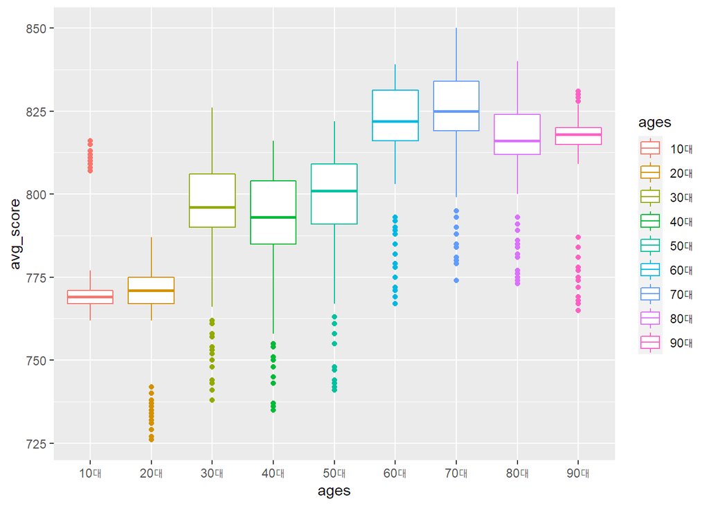

```r
#credit = credit %>% dplyr::select(-"avg_rat")

credit %>%
  ggplot(aes(x=ages, y=avg_score)) +
  geom_boxplot(aes(color=ages))
```

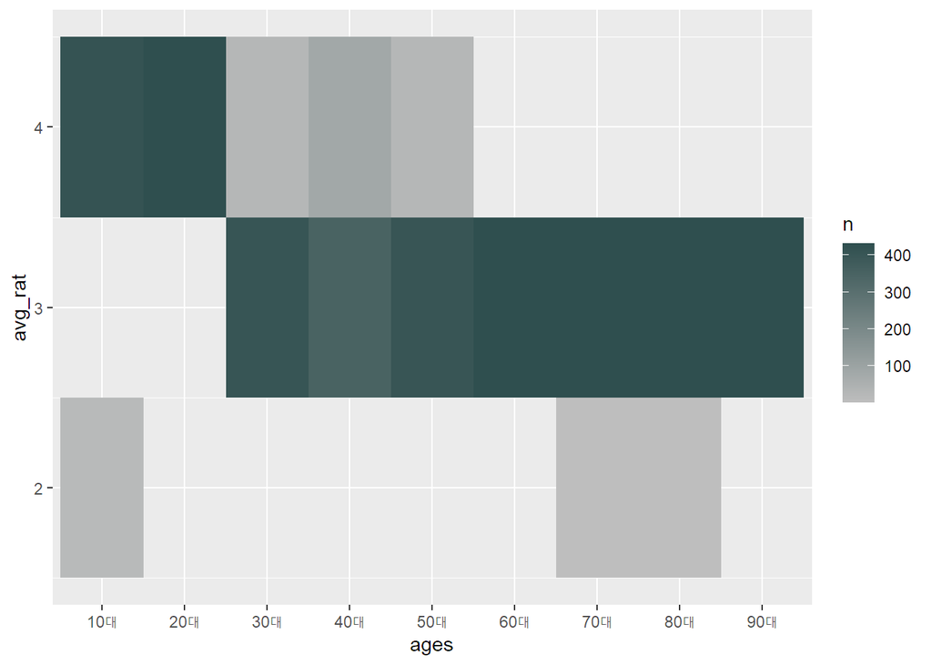

```r
credit %>%
  count(ages, avg_rat) %>%
  ggplot(aes(x=ages, y=avg_rat)) +
  geom_tile((aes(fill=n)))  +
  scale_fill_gradient(low="grey",high="darkslategray")
```

대체로 30대가 되며 안정적인 직장에 자리 잡게 되며 신용점수가 높아진다.  
또한 나이가 들며 더욱 높아지는 것을 알 수 있다.

3. num_usecard(카드사용개수),num_opencard(카드개설개수)

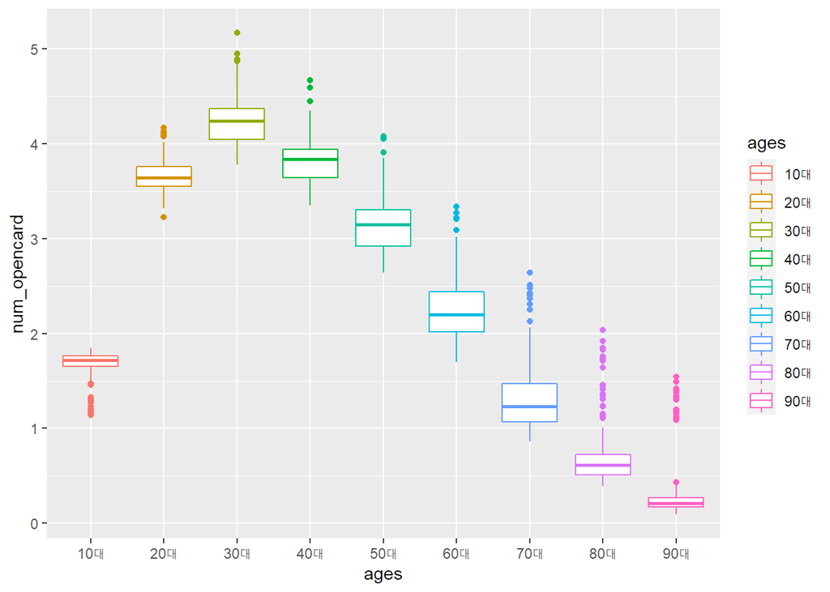

```r
credit %>%
  ggplot(aes(x=ages, y=num_opencard)) +
  geom_boxplot(aes(color=ages))
```

30대에 가장 사회생활을 활발히 하는 나이대로 아직 안정적이지는 않으나  
소비생활을 많이 하게되므로 30대에 가장 카드 개설을 많이 하나 이후 나이가 들며 점점 줄인다.

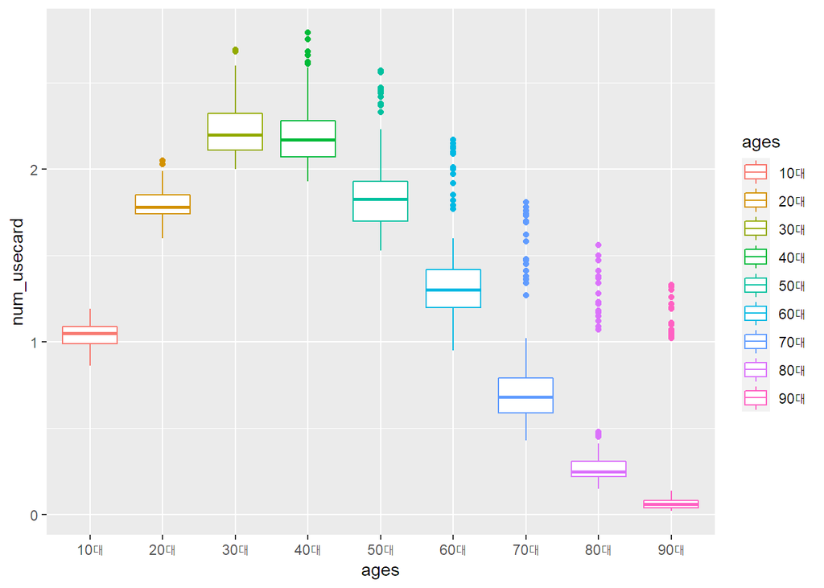

```r
credit %>%
  ggplot(aes(x=ages, y=num_usecard)) +
  geom_boxplot(aes(color=ages))
```

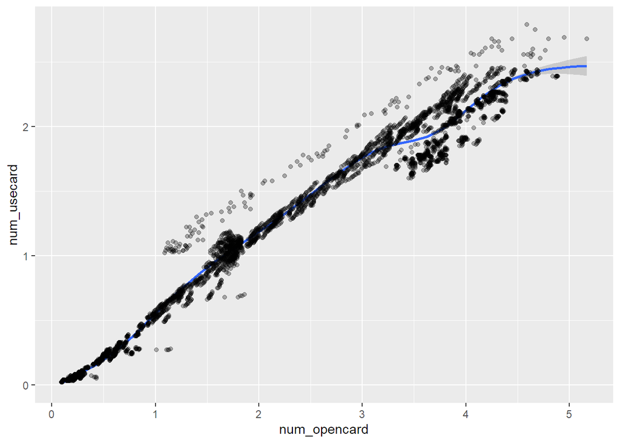

```r
credit %>%
  ggplot(aes(x=num_opencard, y=num_usecard)) +
  geom_smooth() + geom_point(alpha=0.3)
```

사용하는 카드 개수와 카드 개설수가 선형성이 매우 높으므로 하나의 변수로 finance style을 알 수 있다. 대신 카드 사용률에 대한 변수를 생성한다.

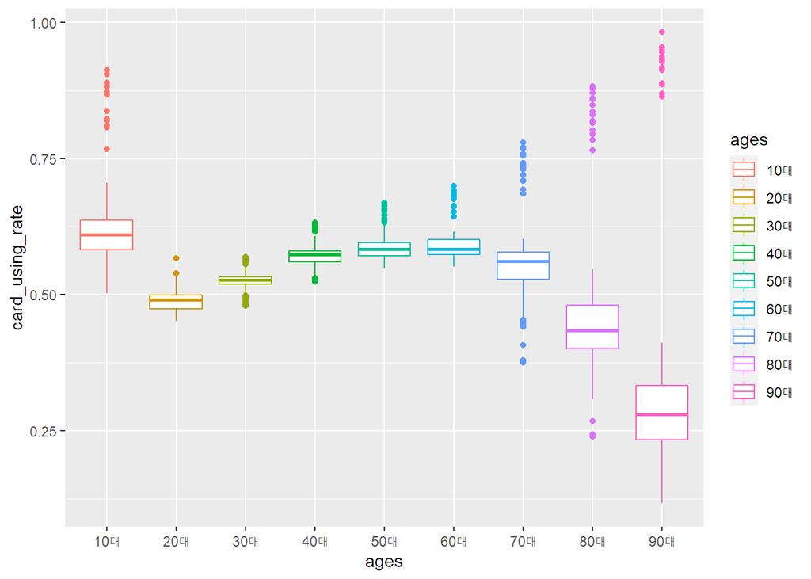

```r
credit %>%
  mutate(card_using_rate = num_usecard/num_opencard) %>%
  ggplot(aes(x=ages, y=card_using_rate)) +
  geom_boxplot(aes(color=ages))
```

4. 월카드 소비액(monthly_card_spend)

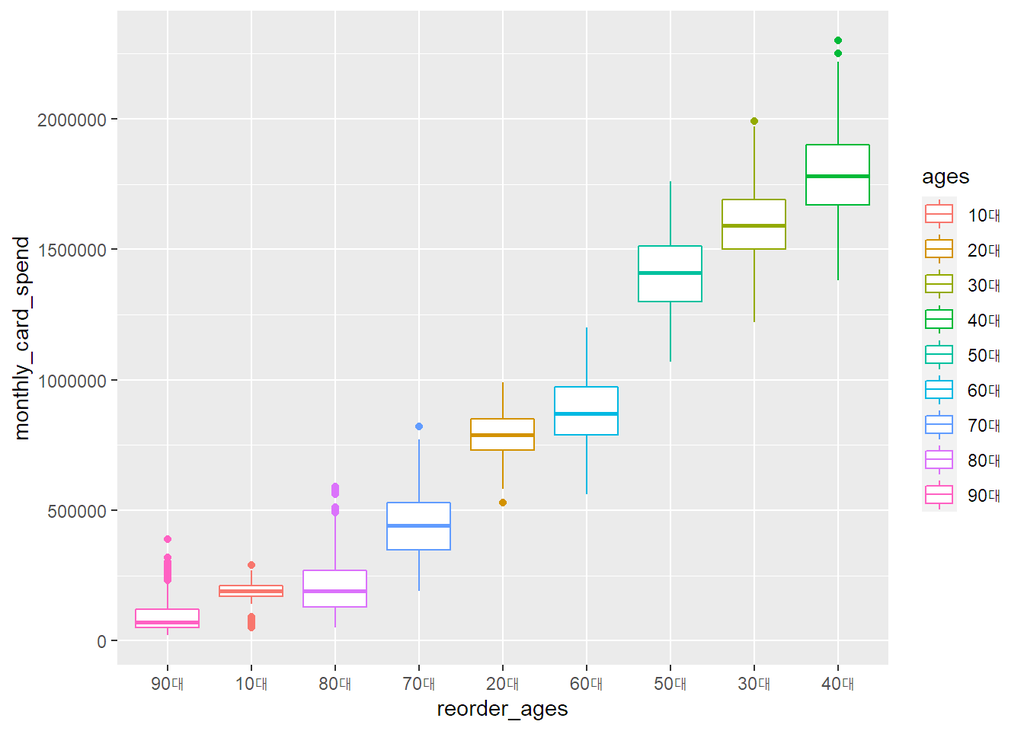

```r
credit %>%
  mutate(reorder_ages = factor(credit$ages, levels=levels(reorder(credit$ages, credit$monthly_card_spend, median, na.rim=TRUE)))) %>%
  ggplot(aes(x=reorder_ages, y=monthly_card_spend)) +
  geom_boxplot(aes(color=ages))
```

5. 대출금액과 각 대출종류에 대한 비율
- monthly_lc: 대출약정금액으로 대출총액과의 차이는 아직 대출금을 받지 않은 경우 -> 이변수는 주관적으로 보았을 때 의미가 없다고 생각

**monthly_sbk_loan - 저축은행**

제2금융권으로 낮은 조건으로 대출을 받을 수 있으나 대출이자가 높다

**monthly_insurance_loan - 보험계약대출**

보험계약의 해지환급금 범위내에서 대출을 받을 수 있는 제도

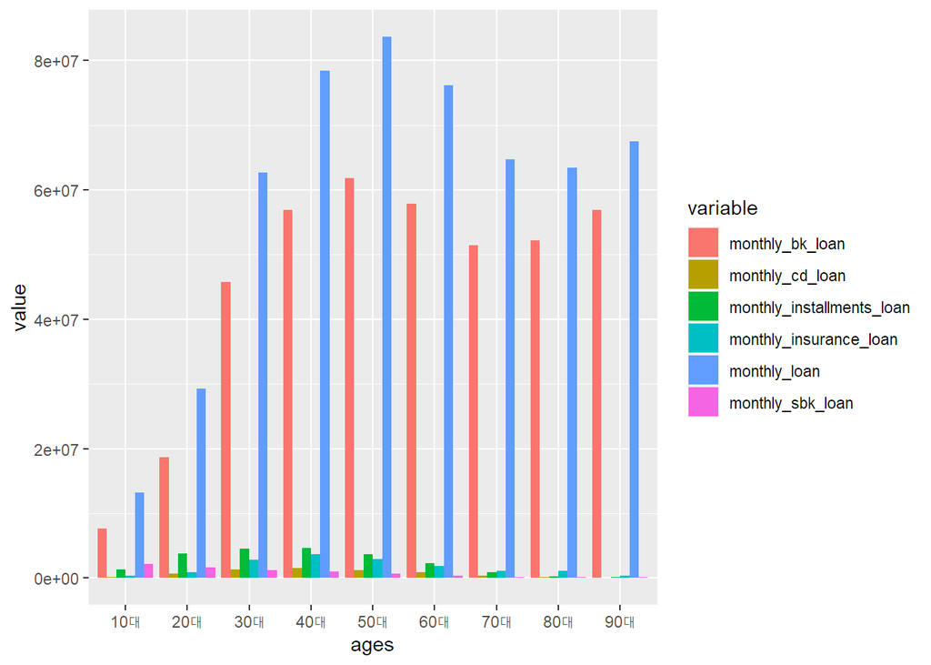

```r
credit %>%
  group_by(ages) %>%
  summarise( monthly_loan = mean(monthly_loan),
             monthly_bk_loan = mean(monthly_bk_loan),
             monthly_cd_loan = mean(monthly_cd_loan),
             monthly_installments_loan = mean(monthly_installments_loan),
             monthly_insurance_loan = mean(monthly_insurance_loan),
             monthly_sbk_loan = mean(monthly_sbk_loan)) %>%
   pivot_longer("monthly_loan":"monthly_sbk_loan",
               values_to = "value", names_to = "variable") %>%
  ggplot() +
  geom_bar(aes(x=ages, y=value, fill=variable), position="dodge", stat="identity")
```

대출종류에 따른 비율을 확인해보자.

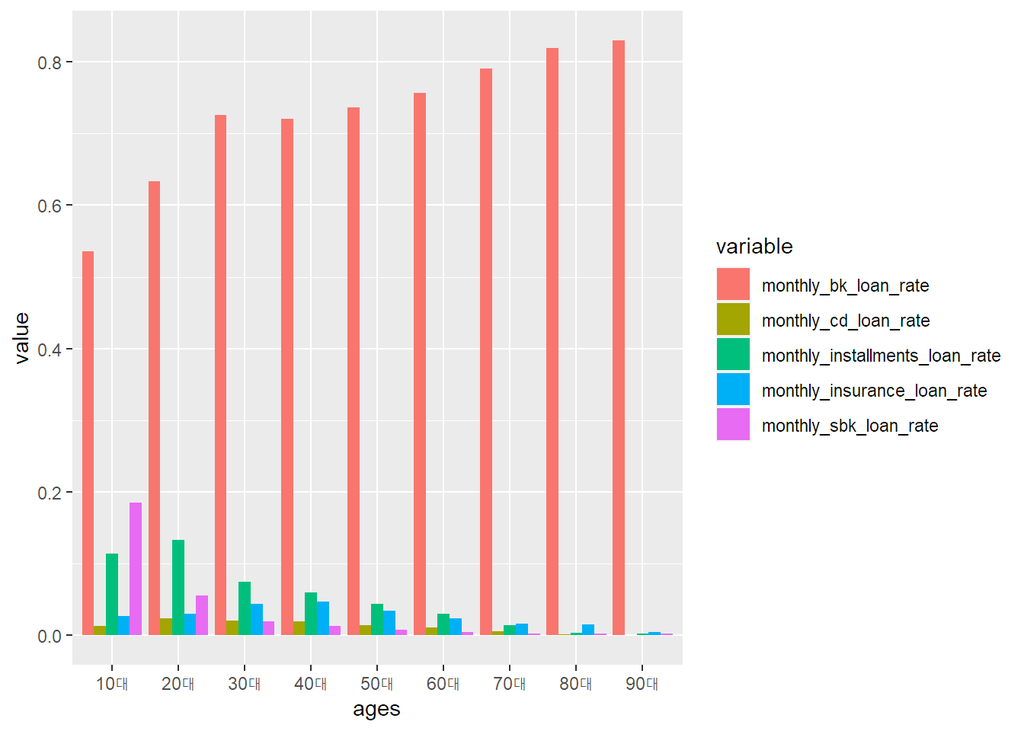

```r
credit %>%
  group_by(ages) %>%
  summarise(monthly_bk_loan_rate = mean( monthly_bk_loan/monthly_loan ),
         monthly_cd_loan_rate = mean( monthly_cd_loan/monthly_loan),
         monthly_installments_loan_rate = mean( monthly_installments_loan/monthly_loan ),
         monthly_insurance_loan_rate = mean( monthly_insurance_loan/monthly_loan),
         monthly_sbk_loan_rate = mean( monthly_sbk_loan/monthly_loan)) %>%
  pivot_longer("monthly_bk_loan_rate":"monthly_sbk_loan_rate",
               values_to = "value", names_to = "variable") %>%
  ggplot() +
  geom_bar(aes(x=ages, y=value, fill=variable), position="dodge", stat="identity")
```

어떤 나이대이든 은행 대출 비율이 가장 높으며 다른 대출종류에 대한 비교 불가하므로 이를 제거하고 비교

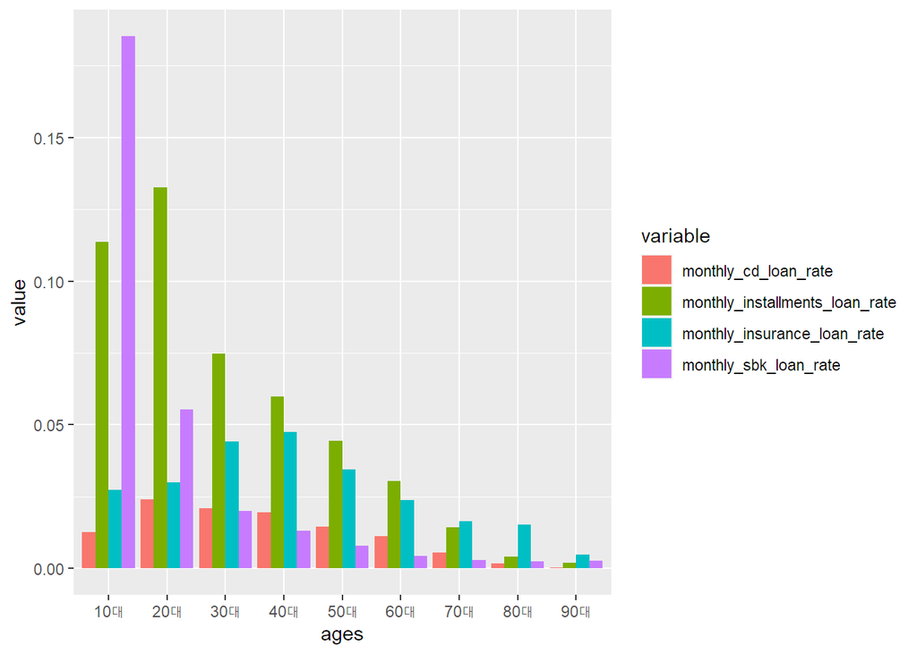

```r
credit %>%
  group_by(ages) %>%
  summarise(
         monthly_cd_loan_rate = mean( monthly_cd_loan/monthly_loan),
         monthly_installments_loan_rate = mean( monthly_installments_loan/monthly_loan ),
         monthly_insurance_loan_rate = mean( monthly_insurance_loan/monthly_loan),
         monthly_sbk_loan_rate = mean( monthly_sbk_loan/monthly_loan)) %>%
  pivot_longer("monthly_cd_loan_rate":"monthly_sbk_loan_rate",
               values_to = "value", names_to = "variable") %>%
  ggplot() +
  geom_bar(aes(x=ages, y=value, fill=variable), position="dodge", stat="identity")
```

10대: 저축은행비율->할부대출비율, 20대: 할부대출비율->저축은행비율, 30,40,50,60대: 할부대출비율->보험대출비율, 70대 이후는 보험대출비율이 가장 높다. -> 10대, 20대는 신용도가 매우 낮으므로 제2금융권에서 많이 대출한 것으로 보인다.

6. 남은 잔액

loan_commitment : 한도 대출 금액(마이너스 통장) inst_rep_loanb : 분할 상환 대출 금액 ls_rep_loanb : 일시 상환 대출 금액 credit_loan : 카드 대출 금액 mortgage_loan : 담보 대출 금액

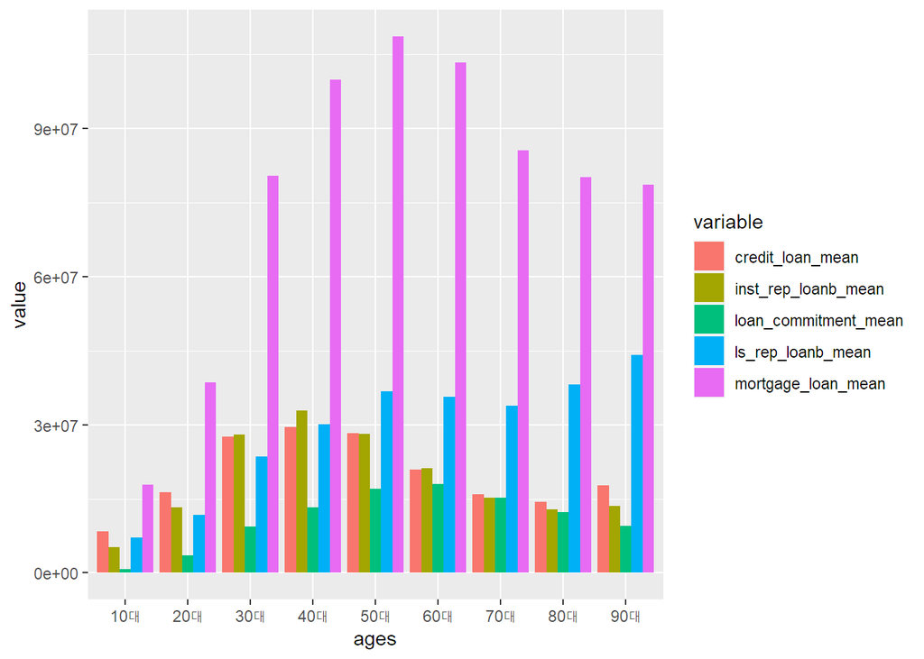

```r
credit %>%
  mutate(all_loanb = inst_rep_loanb + ls_rep_loanb) %>%  #남은 총 대출잔액
  group_by(ages) %>%
  summarise(all_loanb_mean = mean(all_loanb),
            loan_commitment_mean = mean(loan_commitment),
            inst_rep_loanb_mean = mean(inst_rep_loanb),
            ls_rep_loanb_mean = mean(ls_rep_loanb),
            credit_loan_mean = mean(credit_loan),
            mortgage_loan_mean = mean(mortgage_loan)
            ) %>%
  pivot_longer("loan_commitment_mean":"mortgage_loan_mean",
               values_to = "value", names_to = "variable") %>%
  ggplot() +
  geom_bar(aes(x=ages, y=value, fill=variable), position="dodge", stat="identity")
```

주택담보대출은 주로 주택을 구매할 때 필요로 한 비용에 대해 주택을 담보로 대출하므로  
주택을 구매하는 시점부터 대출을 많이 하기 시작

나이가 들수록 분할상환해야하는 장기대출은 줄어들고 일시상환하는 단기대출을 이용한다.

- credit_card_payment(신용카드 사용금액), credit_card_installments_payment(신용카드 할부 사용 금액) 데이터는 이상해보인다…

## 카드사용개수-카드소비액-대출금액-신용점수

- 각 나이대별로 카드 사용 개수에 따른 카드 소비액

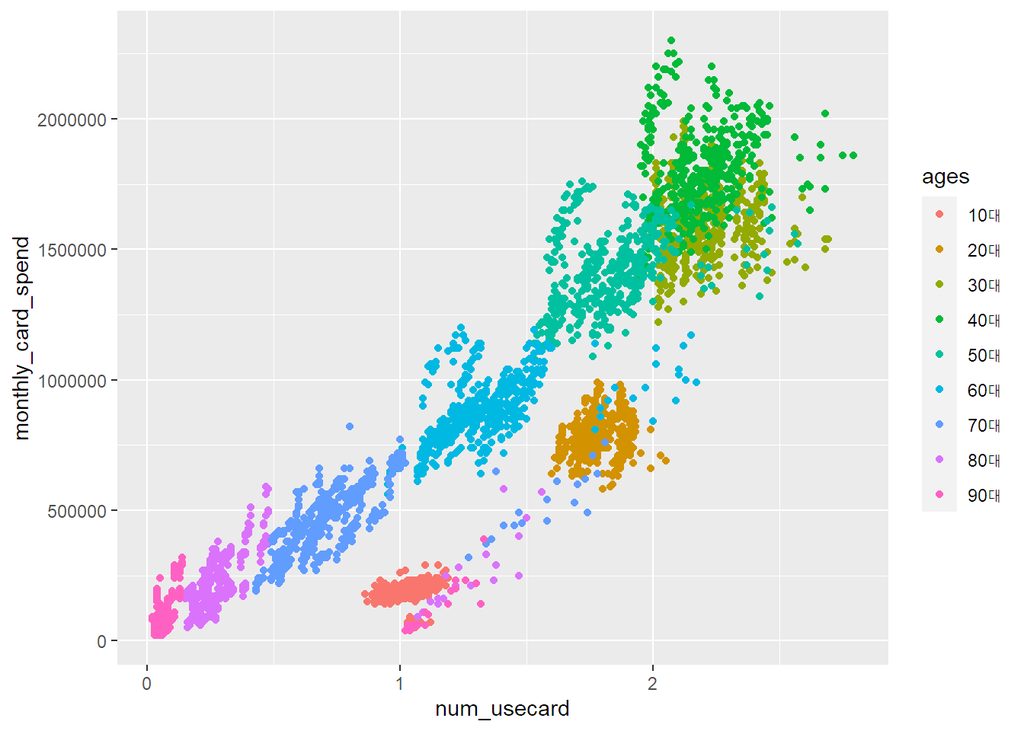

```r
credit %>%
  ggplot(aes(x=num_usecard, y=monthly_card_spend)) +
  geom_point(aes(colour=ages))
```

- 각 나이대별로 카드 사용 개수에 따른 총 대출금액

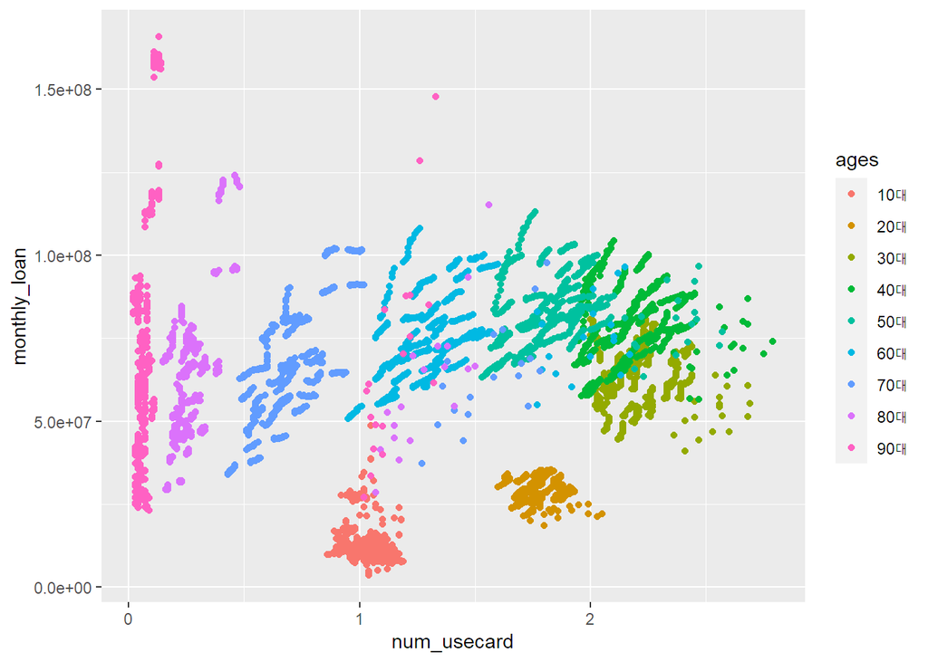

```r
credit %>%
  ggplot(aes(x=num_usecard, y=monthly_loan)) +
  geom_point(aes(colour=ages))
```

- 각 나이대별로 카드소비액과 대출금액 -> 대출금액이 많음에도 40대가 카드소비액 많음

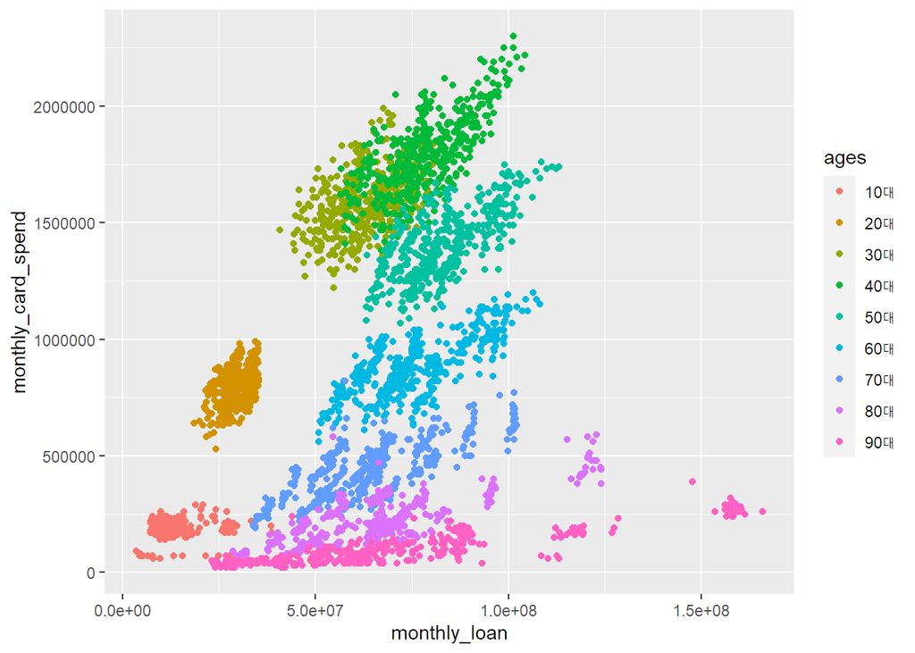

```r
credit %>%
  ggplot(aes(x=monthly_loan, y=monthly_card_spend)) +
  geom_point(aes(colour=ages))
```

- 각 나이대별로 신용점수에 따른 카드사용개수/카드소비액/대출금액

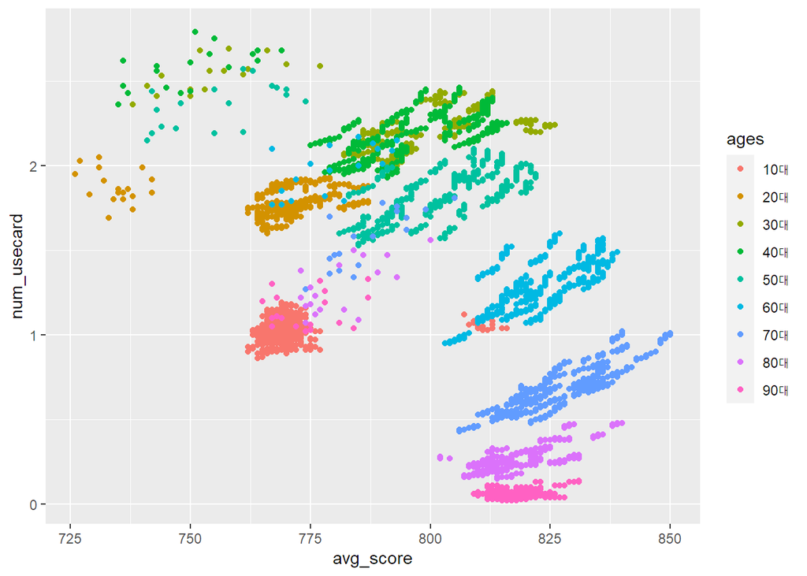

```r
credit %>%
  ggplot(aes(x=avg_score, y=num_usecard)) +
  geom_point(aes(colour=ages))
```

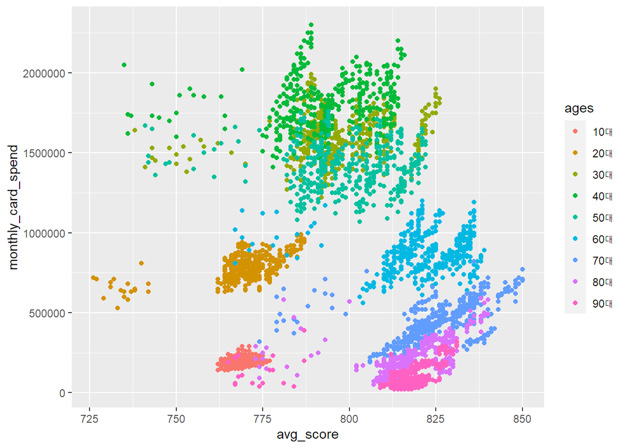

```r
credit %>%
  ggplot(aes(x=avg_score, y=monthly_card_spend)) +
  geom_point(aes(colour=ages))
```

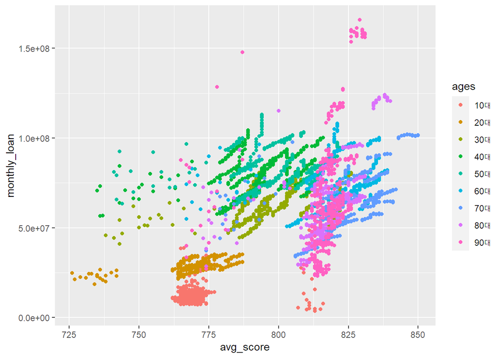

```r
credit %>%
  ggplot(aes(x=avg_score, y=monthly_loan)) +
  geom_point(aes(colour=ages))
```

## 신용등급에 따라 어떤 대출하느냐

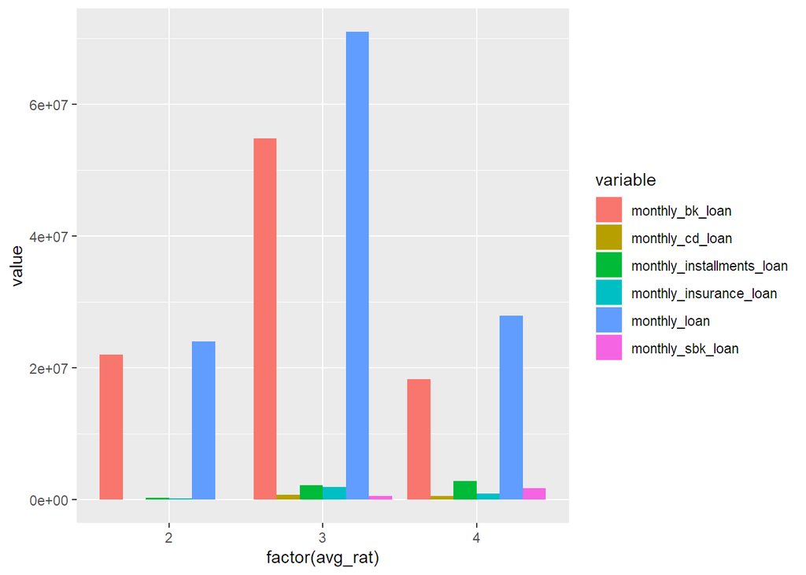

```r
credit %>%
  group_by(avg_rat) %>%
  summarise( monthly_loan = mean(monthly_loan),
             monthly_bk_loan = mean(monthly_bk_loan),
             monthly_cd_loan = mean(monthly_cd_loan),
             monthly_installments_loan = mean(monthly_installments_loan),
             monthly_insurance_loan = mean(monthly_insurance_loan),
             monthly_sbk_loan = mean(monthly_sbk_loan)) %>%
   pivot_longer("monthly_loan":"monthly_sbk_loan",
               values_to = "value", names_to = "variable") %>%
  ggplot() + geom_bar(aes(x=factor(avg_rat), y=value, fill=variable), position="dodge", stat="identity")
```

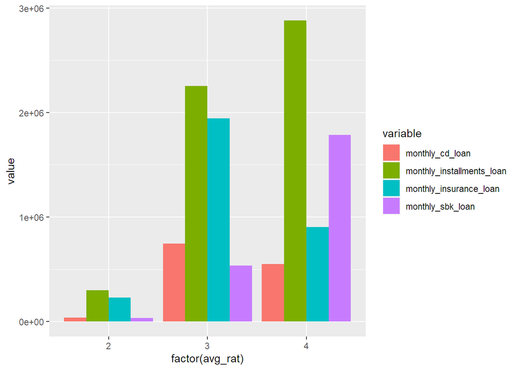

```r
credit %>%
  group_by(avg_rat) %>%
  summarise( monthly_cd_loan = mean(monthly_cd_loan),
             monthly_installments_loan = mean(monthly_installments_loan),
             monthly_insurance_loan = mean(monthly_insurance_loan),
             monthly_sbk_loan = mean(monthly_sbk_loan)) %>%
   pivot_longer("monthly_cd_loan":"monthly_sbk_loan",
               values_to = "value", names_to = "variable") %>%
  ggplot() + geom_bar(aes(x=factor(avg_rat), y=value, fill=variable), position="dodge", stat="identity")
```